# Plantilla 01 — Análisis exploratorio de datos (EDA)

Versión corregida según las observaciones. Ejecuta las celdas en orden en Colab, con `train.csv`, `test.csv` y `sample_submission.csv` en `/content`.

Se mantienen los análisis originales pertinentes. Las repeticiones son una comprobación descriptiva secundaria; el énfasis está en las distribuciones y su relación con `target`. Los resultados deben generarse de nuevo: no se conservan salidas de versiones anteriores.

```python
# Configuración general
DATA_DIR = "/content"

TRAIN_PATH = f"{DATA_DIR}/train.csv"
TEST_PATH = f"{DATA_DIR}/test.csv"
SUBMISSION_PATH = f"{DATA_DIR}/sample_submission.csv"
```

1. Importación de librerías

Cargamos las librerías necesarias. Usaremos pandas para manipulación de datos y matplotlib para visualización.

```python
import os
import warnings

import pandas as pd
import numpy as np
import matplotlib.pyplot as plt
import seaborn as sns

from scipy.stats import f_oneway
from sklearn.feature_selection import mutual_info_classif

warnings.filterwarnings("ignore")

#visual general
sns.set_theme(style="whitegrid")
pd.set_option("display.max_columns", 30)
pd.set_option("display.float_format", lambda x: f"{x:,.4f}")
```

2. Carga e inspección inicial de los datos
- Importa las librerías básicas: pandas, numpy, matplotlib, seaborn.
- Carga el dataset ("pd.read_csv()", "pd.read_excel()", etc.).
- Revisa:
  - "df.shape" → tamaño del dataset (filas, columnas)
  - "df.info()" → tipos de datos y valores nulos
  - "df.head()" / "df.sample()" → primeras filas para una vista general
  - "df.describe()` → estadísticas descriptivas (promedio, desviación, min, max, cuartiles)

```python
#cargar archivos
train = pd.read_csv(TRAIN_PATH)
test = pd.read_csv(TEST_PATH)
sample_submission = pd.read_csv(SUBMISSION_PATH)

#devolver la cantidad de filas y columnas de cada archivo
print("Tamaño del dataset (filas, columnas):")
print(f"train.csv:              {train.shape}")
print(f"test.csv:               {test.shape}")
print(f"sample_submission.csv:  {sample_submission.shape}")

#train.csv
print("TRAIN.CSV")
print("\n1. Tipos de datos y valores nulos:")
train.info()

print("\n3. Primeras filas para una vista general:")
display(train.head())

print("\n4. Estadisticas descriptivas (promedio, desviacion, min, max, cuartiles):")
display(train.describe().T)


#test.csv
print("TEST.CSV")
print("\n1. Tipos de datos y valores nulos:")
test.info()

print("\n3. Primeras filas para una vista general:")
display(test.head())

print("\n4. Estadisticas descriptivas (promedio, desviacion, min, max, cuartiles):")
display(test.describe().T)


#sample_submission.csv
print("SAMPLE_SUBMISSION.CSV")
print("\n1. Tipos de datos y valores nulos:")
sample_submission.info()

print("\n3. Primeras filas para una vista general:")
display(sample_submission.head())

print("\n4. Estadisticas descriptivas (promedio, desviacion, min, max, cuartiles):")
display(sample_submission.describe().T)
```

```
Tamaño del dataset (filas, columnas):
train.csv:              (200000, 202)
test.csv:               (200000, 201)
sample_submission.csv:  (200000, 2)
TRAIN.CSV

1. Tipos de datos y valores nulos:
<class 'pandas.core.frame.DataFrame'>
RangeIndex: 200000 entries, 0 to 199999
Columns: 202 entries, ID_code to var_199
dtypes: float64(200), int64(1), object(1)
memory usage: 308.2+ MB

3. Primeras filas para una vista general:
```

|  | ID_code | target | var_0 | var_1 | var_2 | var_3 | var_4 | var_5 | var_6 | var_7 | var_8 | var_9 | var_10 | var_11 | var_12 | ... | var_185 | var_186 | var_187 | var_188 | var_189 | var_190 | var_191 | var_192 | var_193 | var_194 | var_195 | var_196 | var_197 | … |
| --- | --- | --- | --- | --- | --- | --- | --- | --- | --- | --- | --- | --- | --- | --- | --- | --- | --- | --- | --- | --- | --- | --- | --- | --- | --- | --- | --- | --- | --- | --- |
| 0 | train_0 | 0 | 8.9255 | -6.7863 | 11.9081 | 5.0930 | 11.4607 | -9.2834 | 5.1187 | 18.6266 | -4.9200 | 5.7470 | 2.9252 | 3.1821 | 14.0137 | ... | 5.8764 | 11.8411 | -19.7159 | 17.5743 | 0.5857 | 4.4354 | 3.9642 | 3.1364 | 1.6910 | 18.5227 | -2.3978 | 7.8784 | 8.5635 | … |
| 1 | train_1 | 0 | 11.5006 | -4.1473 | 13.8588 | 5.3890 | 12.3622 | 7.0433 | 5.6208 | 16.5338 | 3.1468 | 8.0851 | -0.4032 | 8.0585 | 14.0239 | ... | -4.8622 | 7.6543 | -15.9319 | 13.3175 | -0.3566 | 7.6421 | 7.7214 | 2.5837 | 10.9516 | 15.4305 | 2.0339 | 8.1267 | 8.7889 | … |
| 2 | train_2 | 0 | 8.6093 | -2.7457 | 12.0805 | 7.8928 | 10.5825 | -9.0837 | 6.9427 | 14.6155 | -4.9193 | 5.9525 | -0.3249 | -11.2648 | 14.1929 | ... | -5.3000 | 5.3745 | -6.2660 | 10.1934 | -0.8417 | 2.9057 | 9.7905 | 1.6704 | 1.6858 | 21.6042 | 3.1417 | -6.5213 | 8.2675 | … |
| 3 | train_3 | 0 | 11.0604 | -2.1518 | 8.9522 | 7.1957 | 12.5846 | -1.8361 | 5.8428 | 14.9250 | -5.8609 | 8.2450 | 2.3061 | 2.8102 | 13.8463 | ... | -0.0498 | 7.9336 | -12.8279 | 12.4124 | 1.8489 | 4.4666 | 4.7433 | 0.7178 | 1.4214 | 23.0347 | -1.2706 | -2.9275 | 10.2922 | … |
| 4 | train_4 | 0 | 9.8369 | -1.4834 | 12.8746 | 6.6375 | 12.2772 | 2.4486 | 5.9405 | 19.2514 | 6.2654 | 7.6784 | -9.4458 | -12.1419 | 13.8481 | ... | -7.8931 | 6.4209 | 5.9270 | 16.0201 | -0.2829 | -1.4905 | 9.5214 | -0.1508 | 9.1942 | 13.2876 | -1.5121 | 3.9267 | 9.5031 | … |

5 rows × 202 columns

```
4. Estadisticas descriptivas (promedio, desviacion, min, max, cuartiles):
```

|  | count | mean | std | min | 25% | 50% | 75% | max |
| --- | --- | --- | --- | --- | --- | --- | --- | --- |
| target | 200,000.0000 | 0.1005 | 0.3007 | 0.0000 | 0.0000 | 0.0000 | 0.0000 | 1.0000 |
| var_0 | 200,000.0000 | 10.6799 | 3.0401 | 0.4084 | 8.4539 | 10.5248 | 12.7582 | 20.3150 |
| var_1 | 200,000.0000 | -1.6276 | 4.0500 | -15.0434 | -4.7400 | -1.6080 | 1.3586 | 10.3768 |
| var_2 | 200,000.0000 | 10.7152 | 2.6409 | 2.1171 | 8.7225 | 10.5800 | 12.5167 | 19.3530 |
| var_3 | 200,000.0000 | 6.7965 | 2.0433 | -0.0402 | 5.2541 | 6.8250 | 8.3241 | 13.1883 |
| ... | ... | ... | ... | ... | ... | ... | ... | ... |
| var_195 | 200,000.0000 | -0.1421 | 1.4294 | -5.2610 | -1.1707 | -0.1727 | 0.8296 | 4.2729 |
| var_196 | 200,000.0000 | 2.3033 | 5.4544 | -14.2096 | -1.9469 | 2.4089 | 6.5567 | 18.3215 |
| var_197 | 200,000.0000 | 8.9082 | 0.9216 | 5.9606 | 8.2528 | 8.8882 | 9.5933 | 12.0004 |
| var_198 | 200,000.0000 | 15.8707 | 3.0109 | 6.2993 | 13.8297 | 15.9340 | 18.0647 | 26.0791 |
| var_199 | 200,000.0000 | -3.3265 | 10.4380 | -38.8528 | -11.2085 | -2.8196 | 4.8368 | 28.5007 |

201 rows × 8 columns

```
TEST.CSV

1. Tipos de datos y valores nulos:
<class 'pandas.core.frame.DataFrame'>
RangeIndex: 200000 entries, 0 to 199999
Columns: 201 entries, ID_code to var_199
dtypes: float64(200), object(1)
memory usage: 306.7+ MB

3. Primeras filas para una vista general:
```

|  | ID_code | var_0 | var_1 | var_2 | var_3 | var_4 | var_5 | var_6 | var_7 | var_8 | var_9 | var_10 | var_11 | var_12 | var_13 | ... | var_185 | var_186 | var_187 | var_188 | var_189 | var_190 | var_191 | var_192 | var_193 | var_194 | var_195 | var_196 | var_197 | … |
| --- | --- | --- | --- | --- | --- | --- | --- | --- | --- | --- | --- | --- | --- | --- | --- | --- | --- | --- | --- | --- | --- | --- | --- | --- | --- | --- | --- | --- | --- | --- |
| 0 | test_0 | 11.0656 | 7.7798 | 12.9536 | 9.4292 | 11.4327 | -2.3805 | 5.8493 | 18.2675 | 2.1337 | 8.8100 | -2.0248 | -4.3554 | 13.9696 | 0.3458 | ... | -1.1651 | 9.2874 | -23.5705 | 13.2643 | 1.6591 | -2.1556 | 11.8495 | -1.4300 | 2.4508 | 13.7112 | 2.4669 | 4.3654 | 10.7200 | … |
| 1 | test_1 | 8.5304 | 1.2543 | 11.3047 | 5.1858 | 9.1974 | -4.0117 | 6.0196 | 18.6316 | -4.4131 | 5.9739 | -1.3809 | -0.3310 | 14.1129 | 2.5667 | ... | -8.8468 | 11.8263 | -8.7112 | 15.9072 | 0.9812 | 10.6165 | 8.8349 | 0.9403 | 10.1282 | 15.5765 | 0.4773 | -1.4852 | 9.8714 | … |
| 2 | test_2 | 5.4827 | -10.3581 | 10.1407 | 7.0479 | 10.2628 | 9.8052 | 4.8950 | 20.2537 | 1.5233 | 8.3442 | -4.7057 | -3.0422 | 13.6751 | 3.8183 | ... | -3.4824 | 4.9178 | -2.0720 | 11.5390 | 1.1821 | -0.7484 | 10.9935 | 1.9803 | 2.1800 | 12.9813 | 2.1281 | -7.1086 | 7.0618 | … |
| 3 | test_3 | 8.5374 | -1.3222 | 12.0220 | 6.5749 | 8.8458 | 3.1744 | 4.9397 | 20.5660 | 3.3755 | 7.4578 | 0.0095 | -5.0659 | 14.0526 | 13.5010 | ... | 3.6638 | 3.3102 | -19.7819 | 13.4499 | 1.3104 | 9.5702 | 9.0766 | 1.6580 | 3.5813 | 15.1874 | 3.1656 | 3.9567 | 9.2295 | … |
| 4 | test_4 | 11.7058 | -0.1327 | 14.1295 | 7.7506 | 9.1035 | -8.5848 | 6.8595 | 10.6048 | 2.9890 | 7.1437 | 5.1025 | -3.2827 | 14.1013 | 8.9672 | ... | 5.8580 | 8.3635 | -24.8254 | 11.4928 | 1.6321 | 4.2259 | 9.1723 | 1.2835 | 3.3778 | 19.5542 | -0.2860 | -5.1612 | 7.2882 | … |

5 rows × 201 columns

```
4. Estadisticas descriptivas (promedio, desviacion, min, max, cuartiles):
```

|  | count | mean | std | min | 25% | 50% | 75% | max |
| --- | --- | --- | --- | --- | --- | --- | --- | --- |
| var_0 | 200,000.0000 | 10.6587 | 3.0367 | 0.1887 | 8.4430 | 10.5138 | 12.7396 | 22.3234 |
| var_1 | 200,000.0000 | -1.6242 | 4.0405 | -15.0434 | -4.7001 | -1.5905 | 1.3434 | 9.3851 |
| var_2 | 200,000.0000 | 10.7075 | 2.6339 | 2.3552 | 8.7356 | 10.5607 | 12.4950 | 18.7141 |
| var_3 | 200,000.0000 | 6.7882 | 2.0527 | -0.0224 | 5.2305 | 6.8224 | 8.3276 | 13.1420 |
| var_4 | 200,000.0000 | 11.0764 | 1.6165 | 5.4844 | 9.8911 | 11.0998 | 12.2534 | 16.0371 |
| ... | ... | ... | ... | ... | ... | ... | ... | ... |
| var_195 | 200,000.0000 | -0.1337 | 1.4297 | -4.9119 | -1.1607 | -0.1620 | 0.8379 | 4.5454 |
| var_196 | 200,000.0000 | 2.2909 | 5.4463 | -13.9442 | -1.9486 | 2.4036 | 6.5198 | 15.9207 |
| var_197 | 200,000.0000 | 8.9124 | 0.9209 | 6.1696 | 8.2601 | 8.8928 | 9.5959 | 12.2758 |
| var_198 | 200,000.0000 | 15.8692 | 3.0087 | 6.5840 | 13.8473 | 15.9434 | 18.0452 | 26.5384 |
| var_199 | 200,000.0000 | -3.2463 | 10.3986 | -39.4578 | -11.1240 | -2.7260 | 4.9354 | 27.9074 |

200 rows × 8 columns

```
SAMPLE_SUBMISSION.CSV

1. Tipos de datos y valores nulos:
<class 'pandas.core.frame.DataFrame'>
RangeIndex: 200000 entries, 0 to 199999
Data columns (total 2 columns):
 #   Column   Non-Null Count   Dtype
---  ------   --------------   -----
 0   ID_code  200000 non-null  object
 1   target   200000 non-null  int64
dtypes: int64(1), object(1)
memory usage: 3.1+ MB

3. Primeras filas para una vista general:
```

|  | ID_code | target |
| --- | --- | --- |
| 0 | test_0 | 0 |
| 1 | test_1 | 0 |
| 2 | test_2 | 0 |
| 3 | test_3 | 0 |
| 4 | test_4 | 0 |

```
4. Estadisticas descriptivas (promedio, desviacion, min, max, cuartiles):
```

|  | count | mean | std | min | 25% | 50% | 75% | max |
| --- | --- | --- | --- | --- | --- | --- | --- | --- |
| target | 200,000.0000 | 0.0000 | 0.0000 | 0.0000 | 0.0000 | 0.0000 | 0.0000 | 0.0000 |

```python
train.nunique().sort_values()
```

|  | 0 |
| --- | --- |
| target | 2 |
| var_68 | 451 |
| var_91 | 7962 |
| var_108 | 8525 |
| var_103 | 9376 |
| ... | ... |
| var_61 | 159369 |
| var_74 | 161058 |
| var_117 | 164469 |
| var_45 | 169968 |
| ID_code | 200000 |

202 rows × 1 columns

**dtype:** int64

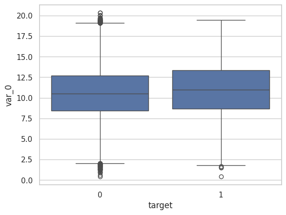

```python
import seaborn as sns

sns.boxplot(data=train, x="target", y="var_0")
plt.show()
```

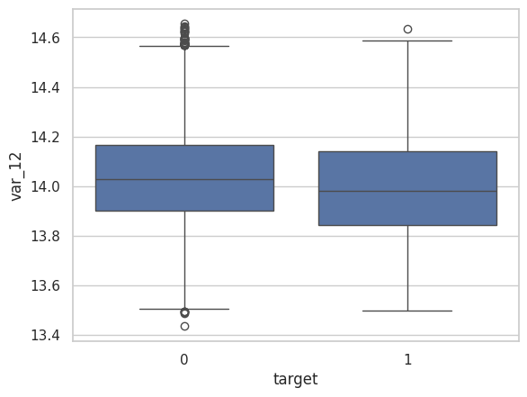

```python
import seaborn as sns

sns.boxplot(data=train, x="target", y="var_12")
plt.show()
```

3. Identificación de tipos de variables Clasifica las columnas:
- Numéricas continuas: edad, salario, temperatura
- Numéricas discretas: número de hijos, cantidad de productos
- Categóricas: género, país, color
- Ordinales: nivel de educación, satisfacción (bajo, medio, alto)
- Fechas o temporales: fecha de compra, hora del evento

```python
#clasificar las columnas

def clasificar_columnas(df):
    continuous_vars = []
    discrete_vars = []
    categoric_vars = []
    ordinal_vars = []
    temporal_vars = []

    for col in df.columns:

        if col == "ID_code":
              continue

        #Fechas/variables temporales
        if pd.api.types.is_datetime64_any_dtype(df[col]):
            temporal_vars.append(col)

        #Numericas
        elif pd.api.types.is_numeric_dtype(df[col]):
            #si tiene valores no enteros es continua
            if not (df[col].dropna() % 1 == 0).all():
                continuous_vars.append(col)
            #si todos son enteros es discreta
            else:
                discrete_vars.append(col)


        #categoricas
        elif pd.api.types.is_object_dtype(df[col]) or \
             pd.api.types.is_categorical_dtype(df[col]):
            categoric_vars.append(col)

    print("Clasificacion de variables")
    print(f"Numericas continuas: {len(continuous_vars)} variables")
    print(f"  Ejemplos: {continuous_vars[:10]}")
    print(f"Numericas discretas: {discrete_vars}")
    print(f"Categoricas: {categoric_vars}")
    print(f"Ordinales: {ordinal_vars if ordinal_vars else 'No hay'}")
    print(f"Temporales: {temporal_vars if temporal_vars else 'No hay'}")

    print("\nTIPOS DE DATOS")
    print(df.dtypes.value_counts())

    return {
        "continuas": continuous_vars,
        "discretas": discrete_vars,
        "categoricas": categoric_vars,
        "ordinales": ordinal_vars,
        "temporales": temporal_vars
    }

clasificacion = clasificar_columnas(train)
```

```
Clasificacion de variables
Numericas continuas: 200 variables
  Ejemplos: ['var_0', 'var_1', 'var_2', 'var_3', 'var_4', 'var_5', 'var_6', 'var_7', 'var_8', 'var_9']
Numericas discretas: ['target']
Categoricas: []
Ordinales: No hay
Temporales: No hay

TIPOS DE DATOS
float64    200
object       1
int64        1
Name: count, dtype: int64
```

```python
#clasificar las columnas
continuous_vars = [c for c in train.columns if c.startswith("var_")]
discrete_vars = ["target"] if "target" in train.columns else []
identifier_vars = ["ID_code"] if "ID_code" in train.columns else []
ordinal_vars = []
temporal_vars = []

print("Clasificacion de variables")
print(f"Numericas continuas: {len(continuous_vars)} variables")
print(f"  Ejemplos: {continuous_vars[:10]}")
print(f"Numericas discretas: {discrete_vars}")
print(f"Identificadores: {identifier_vars}")
print(f"Ordinales: {ordinal_vars if ordinal_vars else 'No hay'}")
print(f"Temporales: {temporal_vars if temporal_vars else 'No hay'}")

print("\nTIPOS DE DATOS")
print(train.dtypes.value_counts())

#comprobacion de variables numéricas
non_numeric_features = [
    c for c in continuous_vars
    if not pd.api.types.is_numeric_dtype(train[c])
]

print("\nVariables var_* con tipo no numerico:", non_numeric_features)
```

```
Clasificacion de variables
Numericas continuas: 200 variables
  Ejemplos: ['var_0', 'var_1', 'var_2', 'var_3', 'var_4', 'var_5', 'var_6', 'var_7', 'var_8', 'var_9']
Numericas discretas: ['target']
Identificadores: ['ID_code']
Ordinales: No hay
Temporales: No hay

TIPOS DE DATOS
float64    200
object       1
int64        1
Name: count, dtype: int64

Variables var_* con tipo no numerico: []
```

4. Limpieza de datos Valores faltantes:
- Identificar ("df.isnull().sum()")
- Decidir si se imputan (media, mediana, moda, interpolación) o se eliminan.

```python
#limpieza sin modificar los dataframes originales
train_clean = train.copy()
test_clean = test.copy()
sample_submission_clean = sample_submission.copy()

feature_cols = [c for c in train_clean.columns if c.startswith("var_")]

#valores que todavia faltna
missing_train = train_clean.isnull().sum()
missing_test = test_clean.isnull().sum()
missing_submission = sample_submission.isnull().sum()

print("Valores faltantes")
print(f"Total en train: {int(missing_train.sum())}")
print(f"Total en test: {int(missing_test.sum())}")
print(f"Total en sample_submission: {int(missing_submission.sum())}")
```

```
Valores faltantes
Total en train: 0
Total en test: 0
Total en sample_submission: 0
```

No se observaron faltantes en la ejecución original. La siguiente imputación es preventiva y no cambia datos si no hay nulos. En la preparación para modelado se calcularán las medianas exclusivamente con la partición de entrenamiento.

```python
#Imputacion con la mediana
#Mediana de cada variable usando train
medians = train_clean[feature_cols].median()

#No es necesario para sample_submission
train_clean[feature_cols] = train_clean[feature_cols].fillna(medians)
test_clean[feature_cols] = test_clean[feature_cols].fillna(medians)


print("\nValores faltantes despues de la imputacion")
print(f"Total en train: {int(train_clean.isnull().sum().sum())}")
print(f"Total en test: {int(test_clean.isnull().sum().sum())}")
print(f"Total en sample_submission: {int(sample_submission_clean.isnull().sum().sum())}")
```

```
Valores faltantes despues de la imputacion
Total en train: 0
Total en test: 0
Total en sample_submission: 0
```

Duplicados:

- Detectar ("df.duplicated()") y eliminar ("df.drop_duplicates()").

```python
#duplicados
duplicates_train = int(train_clean.duplicated().sum())
duplicates_test = int(test_clean.duplicated().sum())
duplicates_sample_submission = int(sample_submission_clean.duplicated().sum())

print("\nDuplicados")
print("Filas duplicadas en train:", duplicates_train)
print("Filas duplicadas en test:", duplicates_test)
print("Filas duplicadas en sample_submission:", duplicates_sample_submission)
```

```
Duplicados
Filas duplicadas en train: 0
Filas duplicadas en test: 0
Filas duplicadas en sample_submission: 0
```

No contamos con duplicados, pero incluímos una sección de código para cumplir con la instrucción.

```python
#eliminar unicamente duplicados exactos si existieran
train_clean = train_clean.drop_duplicates().reset_index(drop=True)
test_clean = test_clean.drop_duplicates().reset_index(drop=True)
sample_submission_clean = sample_submission_clean.drop_duplicates().reset_index(drop=True)

print("\nDuplicados despues de la limpieza")
print("Train:", int(train_clean.duplicated().sum()))
print("Test:", int(test_clean.duplicated().sum()))
print("Filas duplicadas en sample_submission:", int(sample_submission_clean.duplicated().sum()))
```

```
Duplicados despues de la limpieza
Train: 0
Test: 0
Filas duplicadas en sample_submission: 0
```

Outliers (valores atípicos):

- Detectar mediante boxplots, z-score o rango intercuartílico (IQR).

```
Variables con mas outliers en train segun IQR
```

|  | outliers | porcentaje |
| --- | --- | --- |
| var_179 | 1509 | 0.7545 |
| var_44 | 1208 | 0.6040 |
| var_93 | 889 | 0.4445 |
| var_146 | 804 | 0.4020 |
| var_192 | 733 | 0.3665 |
| var_31 | 637 | 0.3185 |
| var_133 | 589 | 0.2945 |
| var_105 | 572 | 0.2860 |
| var_38 | 502 | 0.2510 |
| var_124 | 498 | 0.2490 |
| var_110 | 470 | 0.2350 |
| var_67 | 465 | 0.2325 |
| var_193 | 461 | 0.2305 |
| var_186 | 446 | 0.2230 |
| var_62 | 432 | 0.2160 |

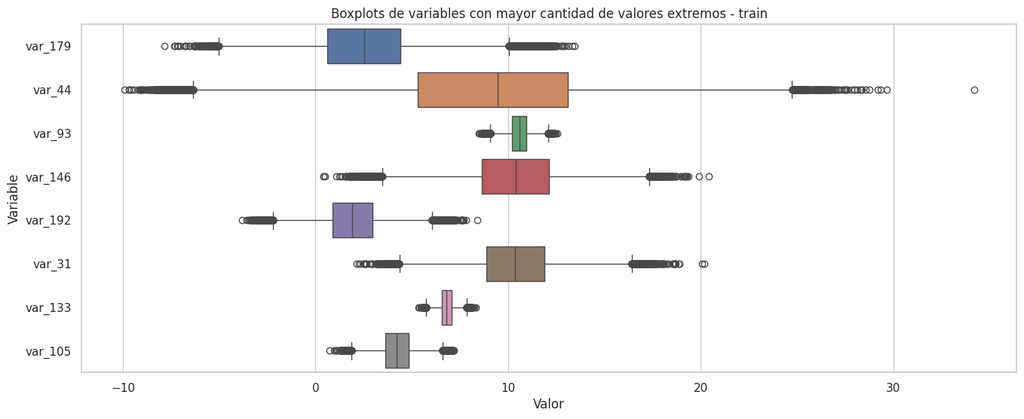

```
Variables con mas outliers en test segun IQR
```

|  | outliers | porcentaje |
| --- | --- | --- |
| var_179 | 1524 | 0.7620 |
| var_44 | 1190 | 0.5950 |
| var_93 | 958 | 0.4790 |
| var_146 | 870 | 0.4350 |
| var_192 | 641 | 0.3205 |
| var_31 | 613 | 0.3065 |
| var_133 | 606 | 0.3030 |
| var_105 | 602 | 0.3010 |
| var_124 | 569 | 0.2845 |
| var_193 | 569 | 0.2845 |
| var_38 | 508 | 0.2540 |
| var_172 | 453 | 0.2265 |
| var_110 | 445 | 0.2225 |
| var_67 | 441 | 0.2205 |
| var_62 | 436 | 0.2180 |

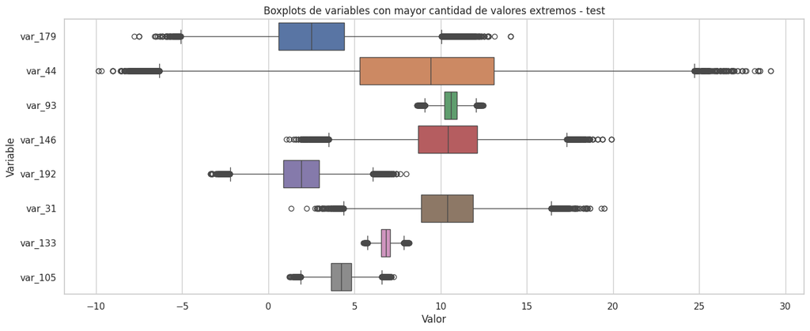

```python
#outlier mediante IQR
def analizar_outliers(df, nombre):

    Q1 = df[feature_cols].quantile(0.25)
    Q3 = df[feature_cols].quantile(0.75)

    IQR = Q3 - Q1

    lower_bound = Q1 - 1.5 * IQR
    upper_bound = Q3 + 1.5 * IQR

    outlier_mask = (
        (df[feature_cols] < lower_bound) |
        (df[feature_cols] > upper_bound)
    )

    outlier_count = outlier_mask.sum().sort_values(ascending=False)

    outlier_pct = (
        outlier_count / len(df) * 100
    ).sort_values(ascending=False)

    outlier_summary = pd.DataFrame({
        "outliers": outlier_count,
        "porcentaje": outlier_pct
    })

    print(f"\nVariables con mas outliers en {nombre} segun IQR")

    display(outlier_summary.head(15))

    #las 8 variables con mayor porcentaje de outliers
    top_outlier_vars = outlier_summary.head(8).index.tolist()

    plt.figure(figsize=(16, 6))
    sns.boxplot(data=df[top_outlier_vars], orient="h")
    plt.title(
        f"Boxplots de variables con mayor cantidad de valores extremos - {nombre}"
    )
    plt.xlabel("Valor")
    plt.ylabel("Variable")
    plt.show()

analizar_outliers(train_clean, "train")
analizar_outliers(test_clean, "test")
```

- Analizar si son errores o casos reales.
- Borrar algunos outliers si es necesario.

Se conservan los valores atípicos: la anonimización impide demostrar que sean errores. Su detección por IQR no justifica por sí sola eliminarlos. Las tablas anteriores permiten revisar su frecuencia en ambos conjuntos.

Tipos de datos incorrectos:

- Convertir strings a fechas ("pd.to_datetime()"), numéricos, etc.

Las variables ya se encuentran en formato numérico (float64), al igual que target (int64), entonces no es necesario convertirlas. ID_code se mantiene como object porque es el identificador. Tampoco se identificaron variables de fecha u hora que requieran conversión.

4. Análisis univariado Analiza cada variable individualmente:
- Numéricas: histogramas, boxplots, medidas de tendencia y dispersión.
- Categóricas: conteos, porcentajes, gráficos de barras.
- Fechas: conteo de eventos por día, mes, año.

Objetivo: entender la distribución, detectar sesgos o escalas anómalas.

Revisión secundaria de valores repetidos. En variables flotantes pueden existir coincidencias por precisión o transformación de los datos. Su frecuencia no demuestra un cargo o depósito constante, ya que desconocemos el significado de las variables. Se reporta también el porcentaje, sin construir predictores a partir de coincidencias poco frecuentes.

```python
features = feature_cols.copy()
resumen_repeticiones = []
for columna in feature_cols:
    conteos = train_clean[columna].value_counts()
    resumen_repeticiones.append({
        "variable": columna,
        "valor_mas_frecuente": conteos.index[0],
        "frecuencia": int(conteos.iloc[0]),
        "porcentaje": 100 * conteos.iloc[0] / len(train_clean)
    })
resumen_repeticiones = pd.DataFrame(resumen_repeticiones).sort_values("frecuencia", ascending=False)
display(resumen_repeticiones.head(20))
```

|  | variable | valor_mas_frecuente | frecuencia | porcentaje |
| --- | --- | --- | --- | --- |
| 68 | var_68 | 5.0214 | 1084 | 0.5420 |
| 108 | var_108 | 14.1999 | 313 | 0.1565 |
| 126 | var_126 | 11.5356 | 305 | 0.1525 |
| 12 | var_12 | 13.5545 | 203 | 0.1015 |
| 91 | var_91 | 6.9785 | 66 | 0.0330 |
| 103 | var_103 | 1.6662 | 61 | 0.0305 |
| 148 | var_148 | 4.0456 | 59 | 0.0295 |
| 71 | var_71 | 0.7031 | 54 | 0.0270 |
| 161 | var_161 | 5.7688 | 52 | 0.0260 |
| 25 | var_25 | 13.6723 | 41 | 0.0205 |
| 125 | var_125 | 12.5159 | 40 | 0.0200 |
| 133 | var_133 | 6.8876 | 39 | 0.0195 |
| 43 | var_43 | 11.4522 | 39 | 0.0195 |
| 169 | var_169 | 5.6941 | 39 | 0.0195 |
| 166 | var_166 | 2.7306 | 39 | 0.0195 |
| 15 | var_15 | 14.6482 | 34 | 0.0170 |
| 131 | var_131 | 0.3544 | 33 | 0.0165 |
| 93 | var_93 | 10.5246 | 32 | 0.0160 |
| 23 | var_23 | 2.9116 | 32 | 0.0160 |
| 34 | var_34 | 11.1229 | 30 | 0.0150 |

El análisis principal describe la forma, dispersión y asimetría de las distribuciones. Una apariencia de campana no demuestra normalidad exacta ni que todas las variables tengan la misma distribución. Los histogramas y las estadísticas permiten examinar esa observación.

```
Resumen univariado de las 200 variables
```

|  | count | mean | std | min | 25% | 50% | 75% | max | median | skewness | iqr |
| --- | --- | --- | --- | --- | --- | --- | --- | --- | --- | --- | --- |
| var_0 | 200,000.0000 | 10.6799 | 3.0401 | 0.4084 | 8.4539 | 10.5248 | 12.7582 | 20.3150 | 10.5248 | 0.2356 | 4.3043 |
| var_1 | 200,000.0000 | -1.6276 | 4.0500 | -15.0434 | -4.7400 | -1.6080 | 1.3586 | 10.3768 | -1.6080 | 0.0531 | 6.0987 |
| var_2 | 200,000.0000 | 10.7152 | 2.6409 | 2.1171 | 8.7225 | 10.5800 | 12.5167 | 19.3530 | 10.5800 | 0.2603 | 3.7942 |
| var_3 | 200,000.0000 | 6.7965 | 2.0433 | -0.0402 | 5.2541 | 6.8250 | 8.3241 | 13.1883 | 6.8250 | -0.0035 | 3.0700 |
| var_4 | 200,000.0000 | 11.0783 | 1.6231 | 5.0748 | 9.8832 | 11.1082 | 12.2611 | 16.6714 | 11.1082 | -0.0482 | 2.3779 |
| ... | ... | ... | ... | ... | ... | ... | ... | ... | ... | ... | ... |
| var_195 | 200,000.0000 | -0.1421 | 1.4294 | -5.2610 | -1.1707 | -0.1727 | 0.8296 | 4.2729 | -0.1727 | 0.1240 | 2.0003 |
| var_196 | 200,000.0000 | 2.3033 | 5.4544 | -14.2096 | -1.9469 | 2.4089 | 6.5567 | 18.3215 | 2.4089 | -0.0325 | 8.5037 |
| var_197 | 200,000.0000 | 8.9082 | 0.9216 | 5.9606 | 8.2528 | 8.8882 | 9.5933 | 12.0004 | 8.8882 | -0.0311 | 1.3405 |
| var_198 | 200,000.0000 | 15.8707 | 3.0109 | 6.2993 | 13.8297 | 15.9340 | 18.0647 | 26.0791 | 15.9340 | -0.1702 | 4.2350 |
| var_199 | 200,000.0000 | -3.3265 | 10.4380 | -38.8528 | -11.2085 | -2.8196 | 4.8368 | 28.5007 | -2.8196 | -0.1643 | 16.0453 |

200 rows × 11 columns

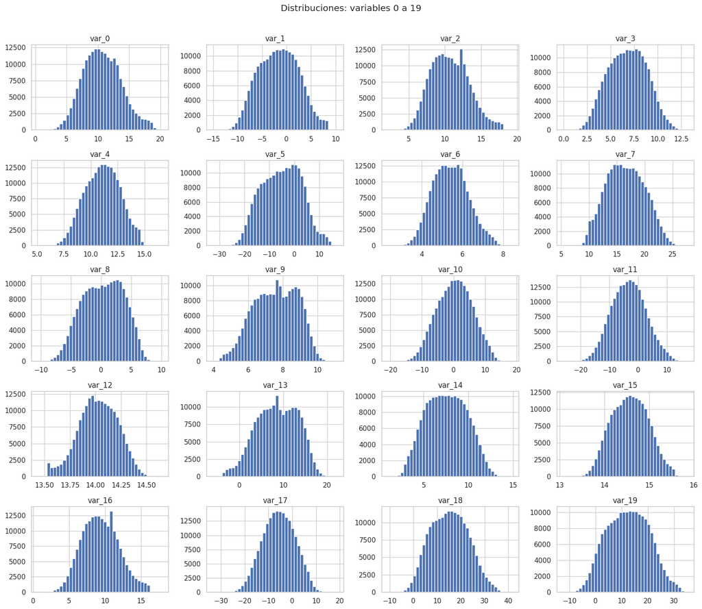

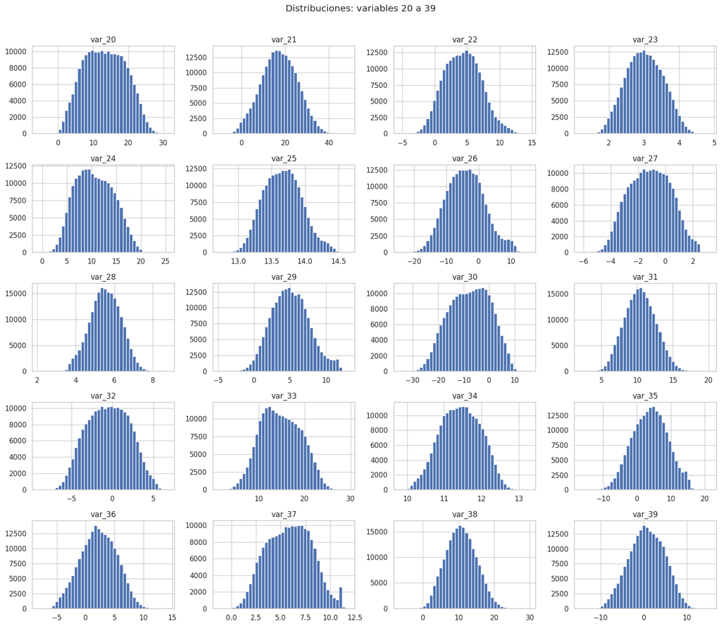

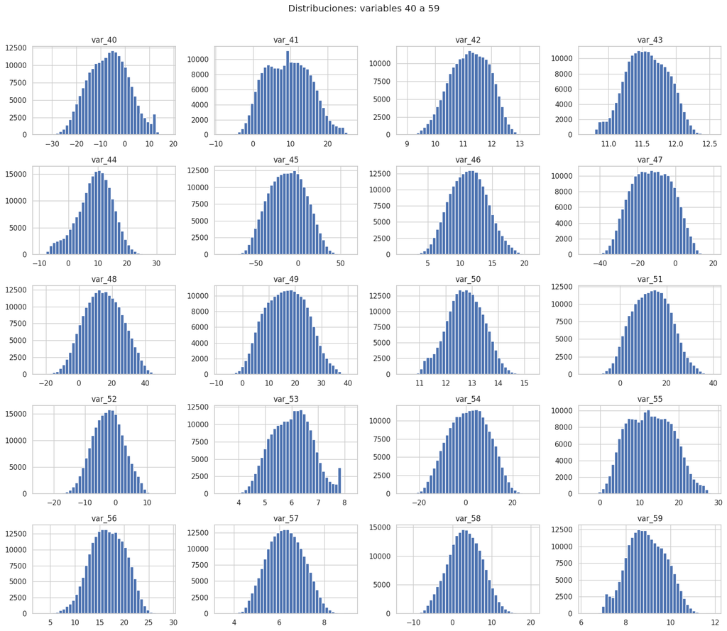

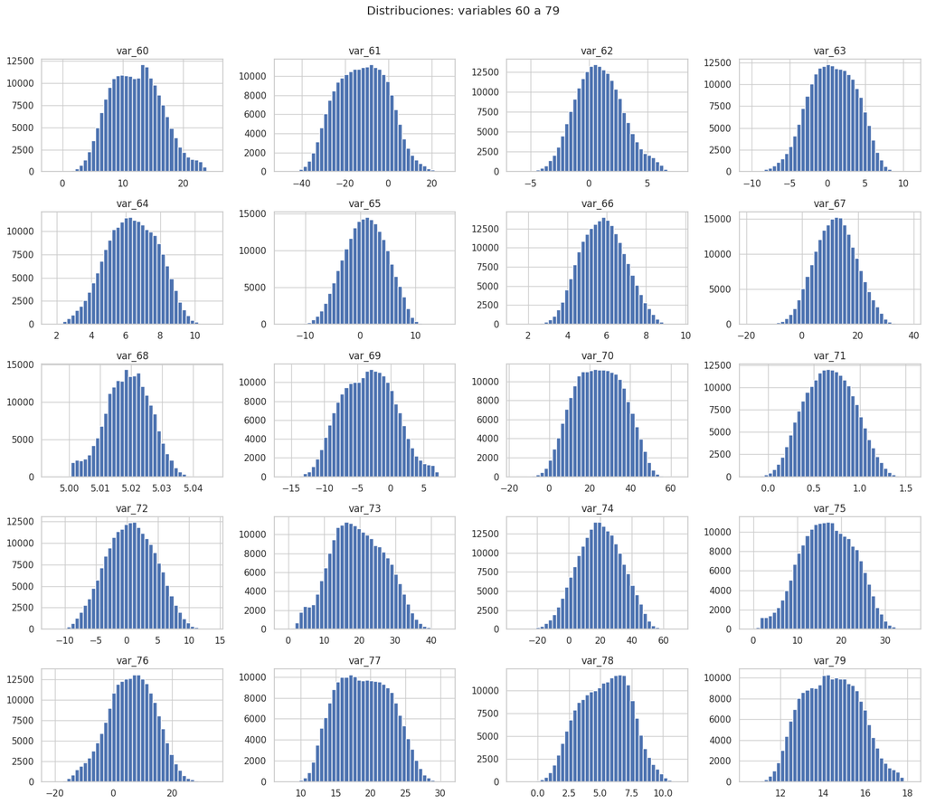

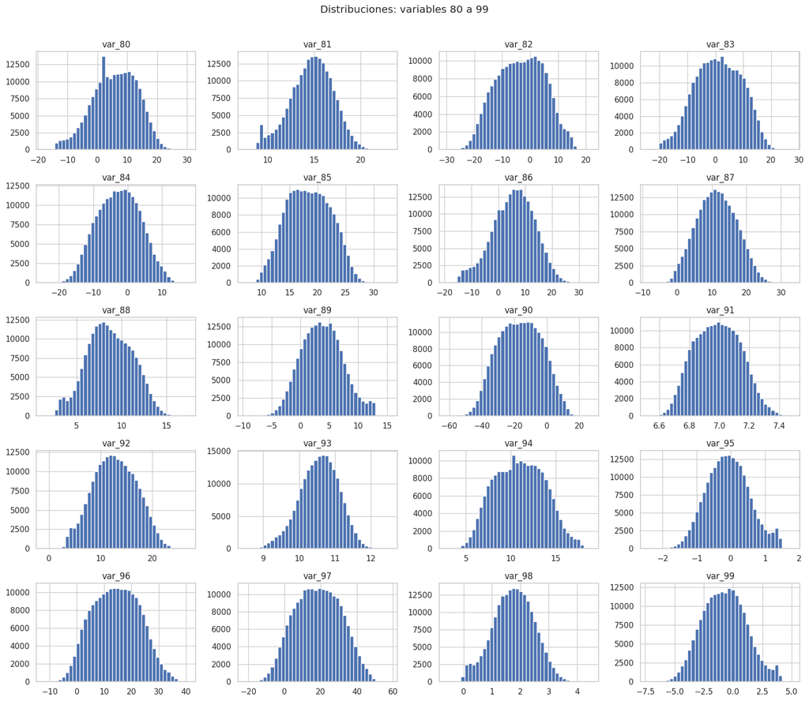

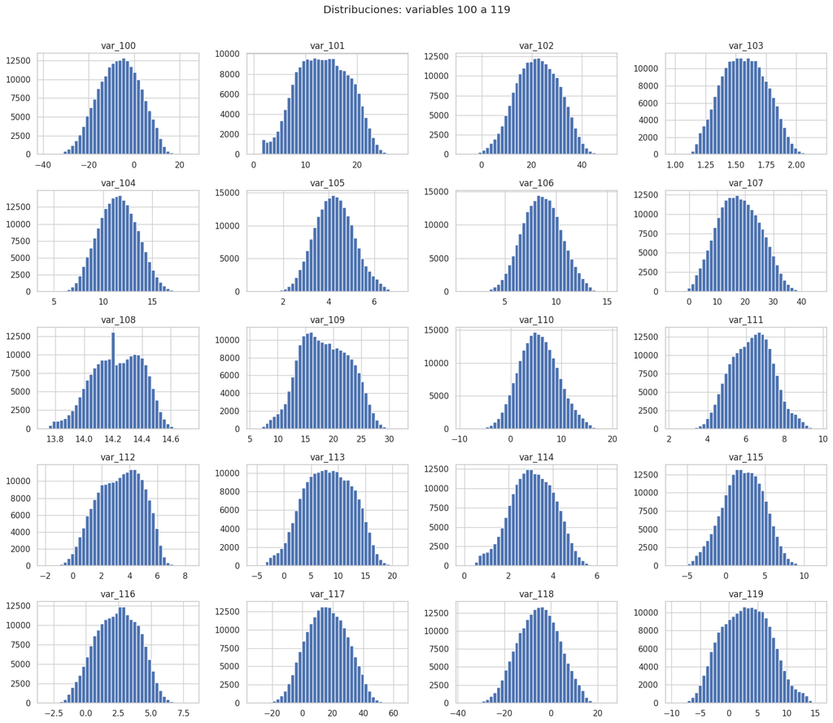

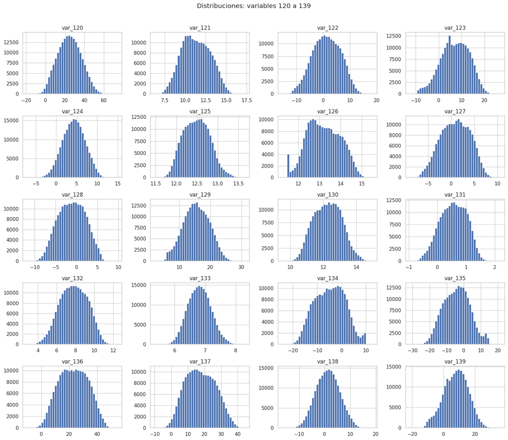

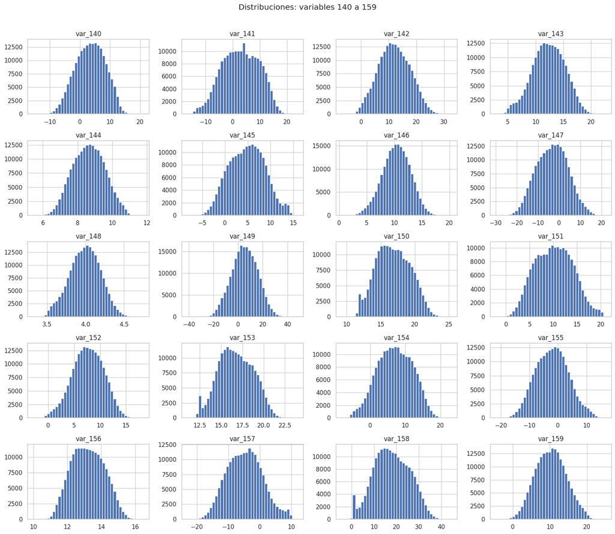

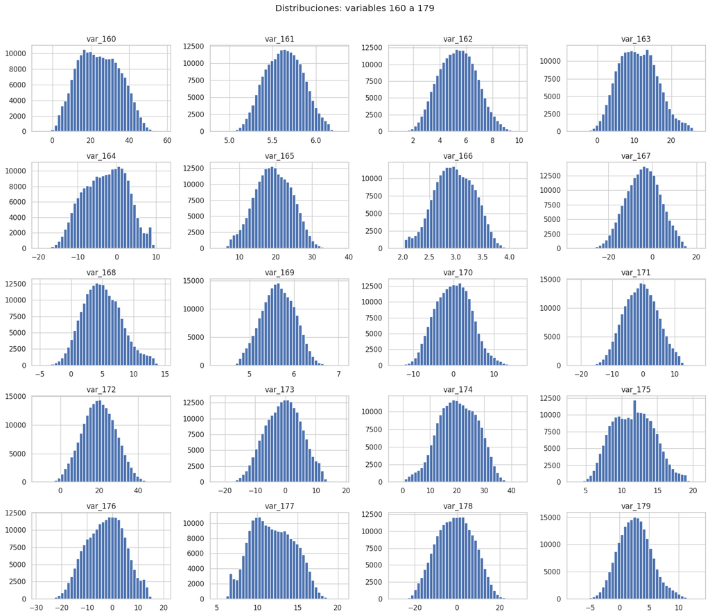

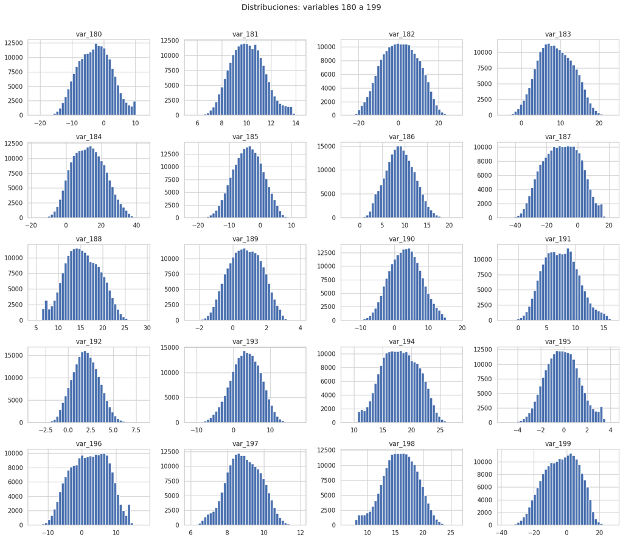

```python
#resumen univariado de las 200 variables
univariate_summary = train_clean[feature_cols].describe().T
univariate_summary["median"] = train_clean[feature_cols].median()
univariate_summary["skewness"] = train_clean[feature_cols].skew()
univariate_summary["iqr"] = (
    univariate_summary["75%"] - univariate_summary["25%"]
)

print("Resumen univariado de las 200 variables")
display(univariate_summary)

# Histogramas de las 200 variables en bloques de 20
for inicio in range(0, len(feature_cols), 20):
    bloque = feature_cols[inicio:inicio + 20]
    train_clean[bloque].hist(bins=40, figsize=(16, 14), layout=(5, 4))
    plt.suptitle(f"Distribuciones: variables {inicio} a {inicio + len(bloque) - 1}")
    plt.tight_layout(rect=(0, 0, 1, 0.97))
    plt.show()
```

Se amplían las 12 variables de mayor asimetría absoluta para revisar dónde la forma se aparta más de la simetría.

```
Variables seleccionadas para visualizacion: ['var_44', 'var_168', 'var_2', 'var_179', 'var_93', 'var_0', 'var_163', 'var_81', 'var_80', 'var_86', 'var_108', 'var_191']
```

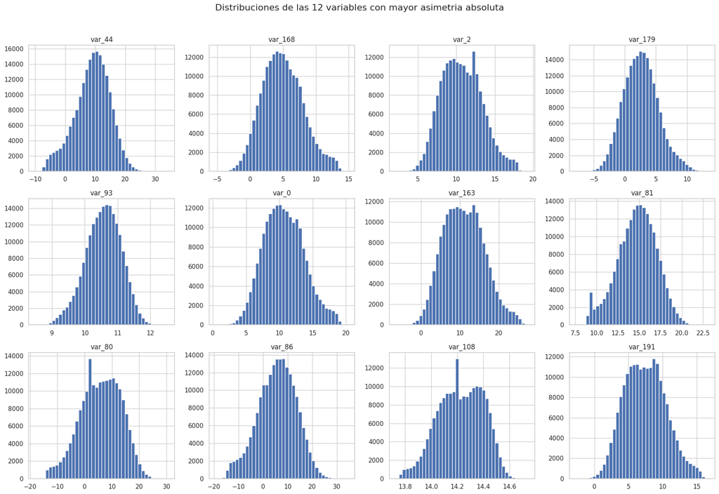

```
Distirbucion de target
```

| target | cantidad | porcentaje |
| --- | --- | --- |
| 0 | 179902 | 89.9510 |
| 1 | 20098 | 10.0490 |

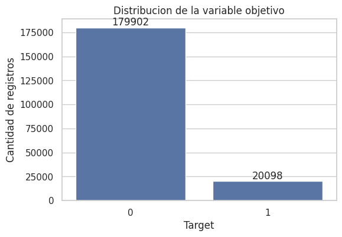

```
Clase 0: 89.95% | Clase 1: 10.05%
```

```python
#Variables con mayor asimetria absoluta
selected_univariate = (
    univariate_summary["skewness"]
    .abs()
    .sort_values(ascending=False)
    .head(12)
    .index
    .tolist()
)

print("Variables seleccionadas para visualizacion:", selected_univariate)

#histogramas
train_clean[selected_univariate].hist(
    bins=40,
    figsize=(18, 12),
    layout=(3, 4)
)
plt.suptitle(
    "Distribuciones de las 12 variables con mayor asimetria absoluta",
    y=1.02,
    fontsize=16
)
plt.tight_layout()
plt.show()

#distribucion de target
target_counts = train_clean["target"].value_counts().sort_index()
target_pct = train_clean["target"].value_counts(normalize=True).sort_index() * 100

target_table = pd.DataFrame({
    "cantidad": target_counts,
    "porcentaje": target_pct
})

print("Distirbucion de target")
display(target_table)

plt.figure(figsize=(6, 4))
ax = sns.countplot(data=train_clean, x="target")
plt.title("Distribucion de la variable objetivo")
plt.xlabel("Target")
plt.ylabel("Cantidad de registros")

for container in ax.containers:
    ax.bar_label(container)

plt.show()

print(
    f"Clase 0: {target_pct.get(0, np.nan):.2f}% | "
    f"Clase 1: {target_pct.get(1, np.nan):.2f}%"
)
```

5. Análisis bivariado y multivariado Explora relaciones entre variables:
- Numérica vs numérica: scatter, correlación ("df.corr()"), mapa de calor.
- Numérica vs categórica: boxplots, violin plots, ANOVA.
- Categórica vs categórica: tablas de contingencia, barras apiladas.
- Con la variable objetivo: detectar patrones que expliquen el *target*.

Primero vamos a análisis con la variable objetivo para detectar patrones que expliquen el target.

```python
def analizar_variable_target(df, col, n_bins=10):

    tmp = df[[col, "target"]].copy()

    tmp["bin"] = pd.qcut(
        tmp[col],
        q=n_bins,
        duplicates="drop"
    )

    resultado = (
        tmp.groupby("bin", observed=True)["target"]
        .agg(["count", "mean"])
        .reset_index()
    )

    resultado["target_pct"] = resultado["mean"] * 100

    return resultado

analizar_variable_target(train_clean, "var_103")
```

|  | bin | count | mean | target_pct |
| --- | --- | --- | --- | --- |
| 0 | (0.978, 1.325] | 20016 | 0.1018 | 10.1769 |
| 1 | (1.325, 1.399] | 19993 | 0.1011 | 10.1135 |
| 2 | (1.399, 1.457] | 20002 | 0.1027 | 10.2740 |
| 3 | (1.457, 1.512] | 20021 | 0.0989 | 9.8946 |
| 4 | (1.512, 1.566] | 20013 | 0.0993 | 9.9335 |
| 5 | (1.566, 1.621] | 19972 | 0.0999 | 9.9940 |
| 6 | (1.621, 1.676] | 20008 | 0.0995 | 9.9510 |
| 7 | (1.676, 1.739] | 19987 | 0.1036 | 10.3617 |
| 8 | (1.739, 1.816] | 20003 | 0.0976 | 9.7585 |
| 9 | (1.816, 2.189] | 19985 | 0.1003 | 10.0325 |

```python
import numpy as np
import pandas as pd

tasa_base = train_clean["target"].mean()

resultados = []

for col in feature_cols:

    #10 grupos del mismo tamaño
    tmp = train_clean[[col, "target"]].copy()

    tmp["bin"] = pd.qcut(
        tmp[col],
        q=10,
        duplicates="drop"
    )

    #Target promedio por bin
    stats = (
        tmp.groupby("bin", observed=True)["target"]
        .agg(["count", "mean"])
        .reset_index()
    )

    #Porcentaje
    stats["target_pct"] = stats["mean"] * 100

    #Lift respecto a la tasa global
    stats["lift"] = stats["mean"] / tasa_base

    #Informacion importante de la variable
    max_idx = stats["mean"].idxmax()
    min_idx = stats["mean"].idxmin()

    resultados.append({
        "Variable": col,

        "Target_Max_%": stats.loc[max_idx, "target_pct"],
        "Target_Min_%": stats.loc[min_idx, "target_pct"],

        "Diferencia_%": (
            stats["target_pct"].max()
            - stats["target_pct"].min()
        ),

        "Max_Lift": stats["lift"].max(),

        "Bin_Mejor": stats.loc[max_idx, "bin"],
        "Bin_Peor": stats.loc[min_idx, "bin"],

        "N_Observaciones_Mejor": int(
            stats.loc[max_idx, "count"]
        )
    })

ranking_variables = pd.DataFrame(resultados)
ranking_variables = ranking_variables.sort_values(
    "Diferencia_%",
    ascending=False
).reset_index(drop=True)

print("TOP 30 VARIABLES POR FUERZA DE SEPARACION")
display(ranking_variables.head(30))
```

```
TOP 30 VARIABLES POR FUERZA DE SEPARACION
```

|  | Variable | Target_Max_% | Target_Min_% | Diferencia_% | Max_Lift | Bin_Mejor | Bin_Peor | N_Observaciones_Mejor |
| --- | --- | --- | --- | --- | --- | --- | --- | --- |
| 0 | var_81 | 18.6491 | 8.1046 | 10.5445 | 1.8558 | (7.585, 11.65] | (15.415, 16.012] | 20001 |
| 1 | var_12 | 16.9039 | 8.2612 | 8.6427 | 1.6822 | (13.434000000000001, 13.78] | (14.026, 14.079] | 20019 |
| 2 | var_139 | 16.9250 | 8.3954 | 8.5296 | 1.6842 | (-21.275000000000002, -2.426] | (14.441, 17.532] | 20000 |
| 3 | var_53 | 16.2974 | 8.3200 | 7.9774 | 1.6218 | (6.978, 8.232] | (3.3440000000000003, 4.999] | 19997 |
| 4 | var_26 | 16.4800 | 8.6700 | 7.8100 | 1.6400 | (3.598, 15.675] | (-11.619, -9.267] | 20000 |
| 5 | var_110 | 16.3650 | 8.6041 | 7.7609 | 1.6285 | (10.566, 19.519] | (4.409, 5.394] | 20000 |
| 6 | var_146 | 16.0442 | 8.4996 | 7.5446 | 1.5966 | (0.426, 7.06] | (12.517, 13.556] | 20001 |
| 7 | var_166 | 15.5750 | 8.0874 | 7.4876 | 1.5499 | (1.85, 2.484] | (3.182, 3.304] | 20000 |
| 8 | var_6 | 15.9100 | 8.4396 | 7.4704 | 1.5832 | (6.557, 8.448] | (2.346, 4.302] | 20000 |
| 9 | var_174 | 15.7550 | 8.4042 | 7.3508 | 1.5678 | (-2.996, 10.998] | (26.83, 29.569] | 20000 |
| 10 | var_22 | 15.7250 | 8.5800 | 7.1450 | 1.5648 | (7.985, 14.594] | (1.726, 2.62] | 20000 |
| 11 | var_76 | 15.4600 | 8.4750 | 6.9850 | 1.5385 | (-21.634, -4.452] | (16.189, 34.435] | 20000 |
| 12 | var_165 | 15.2342 | 8.3200 | 6.9142 | 1.5160 | (3.8160000000000003, 12.758] | (23.866, 25.916] | 20001 |
| 13 | var_109 | 15.3900 | 8.5071 | 6.8829 | 1.5315 | (5.768999999999999, 12.981] | (24.381, 32.059] | 20000 |
| 14 | var_80 | 15.4600 | 8.6250 | 6.8350 | 1.5385 | (-18.043000000000003, -3.978] | (3.802, 6.062] | 20000 |
| 15 | var_21 | 15.1800 | 8.3946 | 6.7854 | 1.5106 | (-10.09, 6.485] | (19.466, 21.793] | 20000 |
| 16 | var_148 | 15.2481 | 8.5677 | 6.6804 | 1.5174 | (3.319, 3.726] | (3.996, 4.048] | 20009 |
| 17 | var_99 | 15.3058 | 8.6537 | 6.6521 | 1.5231 | (1.67, 5.076] | (-2.406, -1.825] | 19999 |
| 18 | var_190 | 15.1500 | 8.5100 | 6.6400 | 1.5076 | (9.256, 18.441] | (-0.82, 0.644] | 20000 |
| 19 | var_133 | 15.1188 | 8.5280 | 6.5908 | 1.5045 | (7.305, 8.309] | (6.481, 6.6] | 19995 |
| 20 | var_34 | 14.7528 | 8.2233 | 6.5295 | 1.4681 | (9.816, 10.722] | (12.153, 13.288] | 20003 |
| 21 | var_2 | 15.0700 | 8.5791 | 6.4909 | 1.4997 | (14.175, 19.353] | (9.826, 10.58] | 20000 |
| 22 | var_179 | 15.3000 | 8.8224 | 6.4776 | 1.5225 | (6.184, 13.449] | (1.787, 2.512] | 20000 |
| 23 | var_78 | 15.0150 | 8.5437 | 6.4713 | 1.4942 | (7.87, 11.351] | (-1.819, 2.639] | 20000 |
| 24 | var_198 | 15.2050 | 8.7559 | 6.4491 | 1.5131 | (6.298, 11.973] | (17.609, 18.553] | 20000 |
| 25 | var_0 | 15.1415 | 8.8200 | 6.3215 | 1.5068 | (14.664, 20.315] | (9.719, 10.525] | 19998 |
| 26 | var_40 | 14.8550 | 8.5959 | 6.2591 | 1.4783 | (3.976, 18.106] | (-14.249, -11.53] | 20000 |
| 27 | var_44 | 15.1850 | 8.9850 | 6.2000 | 1.5111 | (-9.940999999999999, 0.851] | (10.841, 12.298] | 20000 |
| 28 | var_13 | 14.5850 | 8.4350 | 6.1500 | 1.4514 | (-6.0120000000000005, 2.366] | (12.984, 14.533] | 20000 |
| 29 | var_170 | 14.7050 | 8.6600 | 6.0450 | 1.4633 | (5.632, 16.732] | (-14.507, -5.783] | 20000 |

```
las 15 variables con una mayor correlacion absoluta con target son
```

|  | correlacion_target |
| --- | --- |
| var_81 | -0.0809 |
| var_139 | -0.0741 |
| var_12 | -0.0695 |
| var_6 | 0.0667 |
| var_110 | 0.0643 |
| var_146 | -0.0636 |
| var_53 | 0.0634 |
| var_26 | 0.0624 |
| var_76 | -0.0619 |
| var_174 | -0.0617 |
| var_22 | 0.0606 |
| var_21 | -0.0585 |
| var_99 | 0.0584 |
| var_166 | -0.0578 |
| var_80 | -0.0576 |

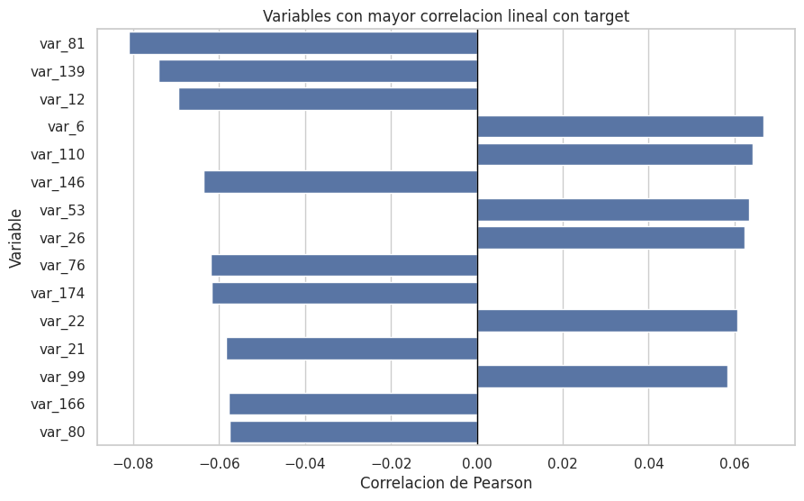

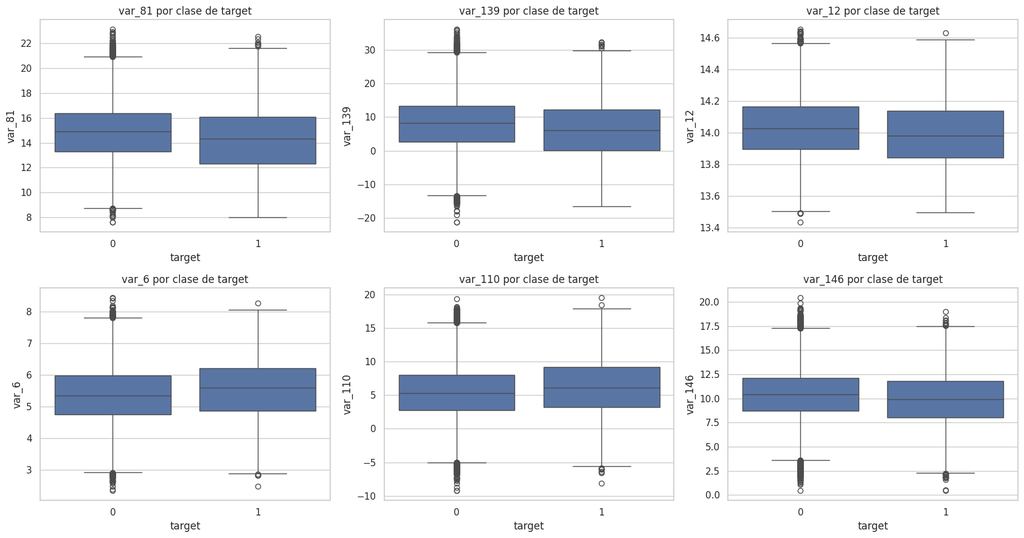

```python
target_corr = (
    train_clean[feature_cols + ["target"]]
    .corr()["target"]
    .drop("target")
    .sort_values(key=np.abs, ascending=False)
)

print("las 15 variables con una mayor correlacion absoluta con target son")
display(target_corr.head(15).to_frame("correlacion_target"))

top_target_vars = target_corr.head(15).index.tolist()

plt.figure(figsize=(10, 6))
sns.barplot(
    x=target_corr.loc[top_target_vars].values,
    y=top_target_vars,
    orient="h"
)
plt.axvline(0, color="black", linewidth=1)
plt.title("Variables con mayor correlacion lineal con target")
plt.xlabel("Correlacion de Pearson")
plt.ylabel("Variable")
plt.show()

#boxplots de las 6 variables más relacionadad con target
top6 = top_target_vars[:6]

fig, axes = plt.subplots(2, 3, figsize=(17, 9))

for ax, var in zip(axes.ravel(), top6):
    sns.boxplot(data=train_clean, x="target", y=var, ax=ax)
    ax.set_title(f"{var} por clase de target")

plt.tight_layout()
plt.show()
```

6. Correlaciones y multicolinealidad
- Usa "df.corr()" para medir relaciones lineales.
- Visualiza con mapas de calor (heatmap).
- Si dos variables están muy correlacionadas (> 0.9), considera eliminar una para evitar redundancia.

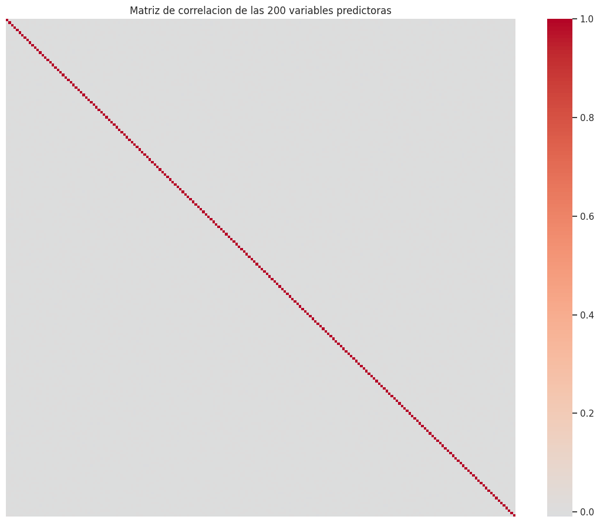

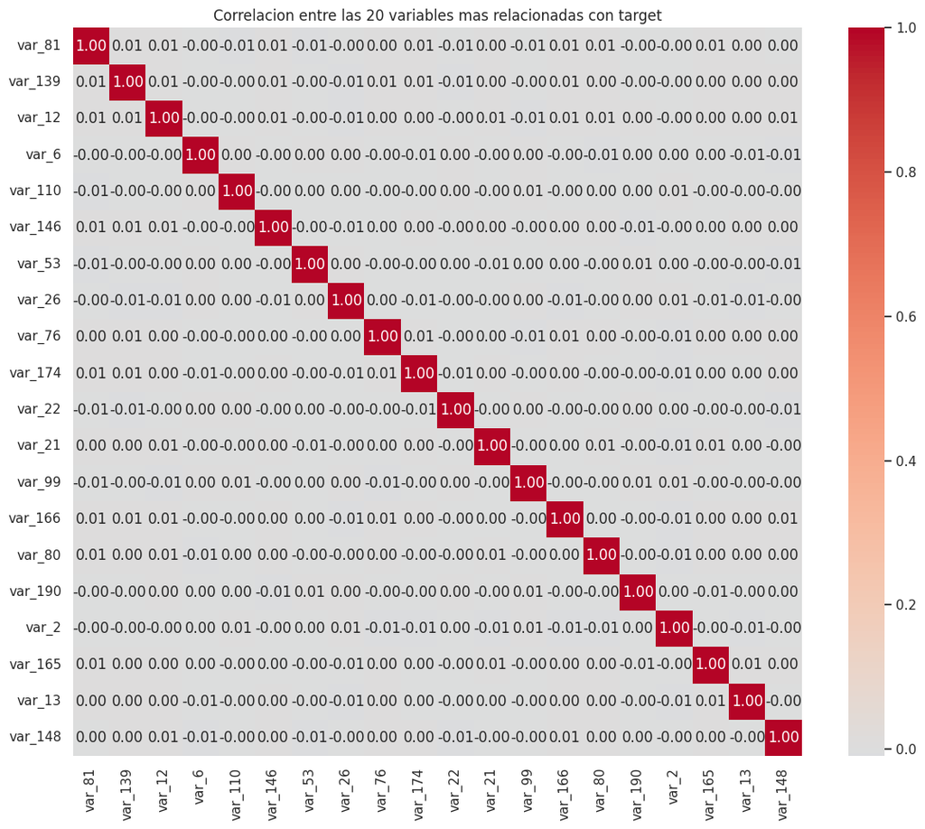

```
Pares de variables con |CORRELACIÓN| > 0.90
No se encontraron pares con correlacion absoluta superior a 0.90.

Candidatas a eliminacion por multicolinealidad: []
```

```python
#matriz completa de correlación entre variables predictoras
feature_corr = train_clean[feature_cols].corr()

#mapa de calor general
plt.figure(figsize=(14, 11))
sns.heatmap(
    feature_corr,
    cmap="coolwarm",
    center=0,
    xticklabels=False,
    yticklabels=False
)
plt.title("Matriz de correlacion de las 200 variables predictoras")
plt.show()

#mapa de calor de las 20 variables mas asociadas a target
top20 = target_corr.head(20).index.tolist()

plt.figure(figsize=(14, 11))
sns.heatmap(
    feature_corr.loc[top20, top20],
    annot=True,
    fmt=".2f",
    cmap="coolwarm",
    center=0,
    square=True
)
plt.title("Correlacion entre las 20 variables mas relacionadas con target")
plt.show()

# deteccion de pares
upper_triangle = feature_corr.where(
    np.triu(np.ones(feature_corr.shape), k=1).astype(bool)
)

high_corr_pairs = (
    upper_triangle.stack()
    .rename("correlation")
    .reset_index()
)

high_corr_pairs["abs_correlation"] = high_corr_pairs["correlation"].abs()

high_corr_pairs = (
    high_corr_pairs[high_corr_pairs["abs_correlation"] > 0.90]
    .sort_values("abs_correlation", ascending=False)
)

print("Pares de variables con |CORRELACIÓN| > 0.90")

if high_corr_pairs.empty:
    print("No se encontraron pares con correlacion absoluta superior a 0.90.")
else:
    display(high_corr_pairs)

#variables candidatas a eliminar solo por multicolinealidad
vars_to_drop_multicollinearity = (
    high_corr_pairs["level_1"].unique().tolist()
    if not high_corr_pairs.empty
    else []
)

print("\nCandidatas a eliminacion por multicolinealidad:", vars_to_drop_multicollinearity)
```

Se complementa la revisión de correlación entre "var_0" y "var_199".

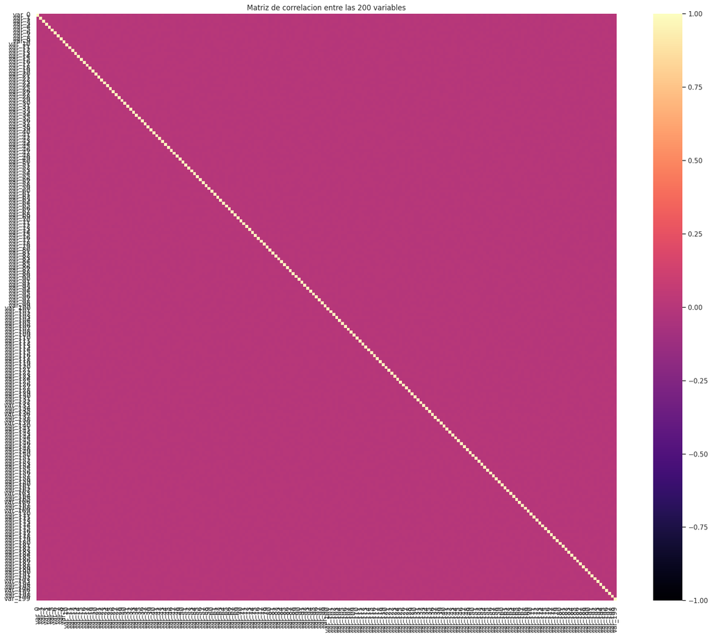

```python
X = train_clean[feature_cols]

corr_matrix = X.corr()

plt.figure(figsize=(18, 15))

sns.heatmap(
    corr_matrix,
    cmap="magma",
    center=0,
    vmin=-1,
    vmax=1,
    xticklabels=True,
    yticklabels=True
)

plt.title("Matriz de correlacion entre las 200 variables")
plt.tight_layout()
plt.show()
```

```python
#Variables con más correlación
corr_pairs = (
    corr_matrix
    .where(
        np.triu(
            np.ones(corr_matrix.shape),
            k=1
        ).astype(bool)
    )
    .stack()
    .sort_values(
        key=np.abs,
        ascending=False
    )
)

print("20 pares de variables con mayor correlacion absoluta:")

display(
    corr_pairs
    .head(20)
    .to_frame("correlacion")
)
```

```
20 pares de variables con mayor correlacion absoluta:
```

|  |  | correlacion |
| --- | --- | --- |
| var_26 | var_139 | -0.0098 |
| var_53 | var_148 | -0.0098 |
| var_81 | var_165 | 0.0097 |
|  | var_174 | 0.0095 |
| var_183 | var_189 | 0.0094 |
| var_146 | var_169 | 0.0091 |
| var_6 | var_80 | -0.0090 |
| var_122 | var_132 | 0.0090 |
| var_81 | var_172 | 0.0089 |
| var_1 | var_80 | -0.0089 |
| var_2 | var_13 | -0.0088 |
| var_81 | var_155 | -0.0086 |
| var_12 | var_146 | 0.0086 |
| var_127 | var_162 | -0.0086 |
| var_54 | var_179 | -0.0084 |
| var_172 | var_193 | 0.0082 |
| var_6 | var_157 | 0.0081 |
| var_26 | var_72 | -0.0081 |
| var_167 | var_173 | 0.0080 |
| var_34 | var_133 | -0.0080 |

7. Detección de patrones y relaciones no lineales
- Explorar posibles interacciones entre variables.
- Usar gráficos de dispersión por categorías, pairplots, jointplots.
- Identificar relaciones no lineales o dependencias complejas.

Ya que no encontramos relaciones lineales entre variables buscamos relaciones monótonas con spearman.

```python
#Relaciones no lineales.
spearman_corr = X.corr(method="spearman")

spearman_pairs = (
    spearman_corr
    .where(
        np.triu(
            np.ones(spearman_corr.shape),
            k=1
        ).astype(bool)
    )
    .stack()
    .sort_values(
        key=np.abs,
        ascending=False
    )
)

print("20 pares con mayor correlacion de Spearman:")
display(
    spearman_pairs.head(20).to_frame("correlacion_spearman")
)
```

```
20 pares con mayor correlacion de Spearman:
```

|  |  | correlacion_spearman |
| --- | --- | --- |
| var_26 | var_139 | -0.0097 |
| var_183 | var_189 | 0.0094 |
| var_122 | var_132 | 0.0090 |
| var_53 | var_148 | -0.0089 |
| var_81 | var_165 | 0.0086 |
| var_6 | var_80 | -0.0084 |
| var_50 | var_157 | -0.0083 |
| var_6 | var_157 | 0.0083 |
| var_81 | var_174 | 0.0082 |
| var_121 | var_149 | 0.0082 |
| var_81 | var_155 | -0.0081 |
| var_146 | var_169 | 0.0081 |
| var_172 | var_193 | 0.0080 |
| var_54 | var_179 | -0.0079 |
| var_34 | var_138 | -0.0079 |
| var_127 | var_162 | -0.0078 |
| var_10 | var_163 | -0.0078 |
| var_0 | var_123 | -0.0078 |
| var_12 | var_123 | 0.0078 |
| var_92 | var_164 | -0.0077 |

```python
corr_matrix.abs().stack().describe()
```

|  | 0 |
| --- | --- |
| count | 40,000.0000 |
| mean | 0.0070 |
| std | 0.0704 |
| min | 0.0000 |
| 25% | 0.0008 |
| 50% | 0.0017 |
| 75% | 0.0029 |
| max | 1.0000 |

**dtype:** float64

```python
corr_pairs = (
    corr_matrix
    .where(
        np.triu(
            np.ones(corr_matrix.shape),
            k=1
        ).astype(bool)
    )
    .stack()
)

corr_pairs.abs().describe()
```

|  | 0 |
| --- | --- |
| count | 19,900.0000 |
| mean | 0.0020 |
| std | 0.0015 |
| min | 0.0000 |
| 25% | 0.0008 |
| 50% | 0.0017 |
| 75% | 0.0029 |
| max | 0.0098 |

**dtype:** float64

La correlación de Spearman explora relaciones monótonas. A continuación se estima información mutua entre cada predictor y target, no entre pares de predictores.

```python
from sklearn.feature_selection import mutual_info_classif

#Muestra para acelerar el cálculo
mi_sample = train_clean.sample(
    n=min(10000, len(train_clean)),
    random_state=42
)

X_sample = mi_sample[feature_cols]
y_sample = mi_sample["target"]

mi = mutual_info_classif(
    X_sample,
    y_sample,
    random_state=42,
    n_neighbors=3
)

mi_df = pd.DataFrame({
    "variable": feature_cols,
    "mutual_information": mi
}).sort_values(
    "mutual_information",
    ascending=False
)

display(mi_df.head(20))
```

|  | variable | mutual_information |
| --- | --- | --- |
| 81 | var_81 | 0.0092 |
| 22 | var_22 | 0.0078 |
| 179 | var_179 | 0.0076 |
| 139 | var_139 | 0.0072 |
| 34 | var_34 | 0.0068 |
| 30 | var_30 | 0.0066 |
| 190 | var_190 | 0.0065 |
| 119 | var_119 | 0.0059 |
| 130 | var_130 | 0.0058 |
| 197 | var_197 | 0.0058 |
| 88 | var_88 | 0.0058 |
| 122 | var_122 | 0.0054 |
| 31 | var_31 | 0.0052 |
| 19 | var_19 | 0.0052 |
| 29 | var_29 | 0.0051 |
| 143 | var_143 | 0.0050 |
| 95 | var_95 | 0.0046 |
| 76 | var_76 | 0.0046 |
| 57 | var_57 | 0.0045 |
| 159 | var_159 | 0.0044 |

Una asociación individual débil no descarta señal predictiva conjunta. Se comparan las distribuciones por clase de "var_81", normalizando cada clase por separado.

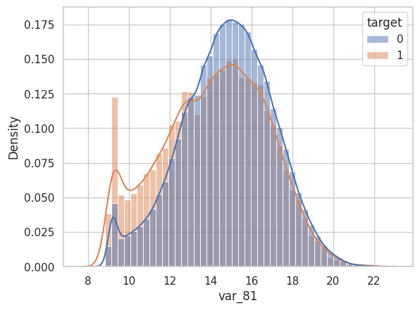

```python
sns.histplot(
    data=train,
    x="var_81",
    hue="target",
    kde=True,
    stat="density",
    common_norm=False,
    bins=50
)

plt.show()
```

```python
from sklearn.metrics import roc_auc_score
import pandas as pd
import numpy as np

auc_results = []

for col in features:
    auc = roc_auc_score(
        train["target"],
        train[col]
    )

    auc_results.append({
        "feature": col,
        "auc": auc,
        "auc_strength": max(auc, 1 - auc),
        "direction": "positiva" if auc >= 0.5 else "inversa"
    })

auc_df = pd.DataFrame(auc_results)

auc_df = auc_df.sort_values(
    "auc_strength",
    ascending=False
)

auc_df.head(30)
```

|  | feature | auc | auc_strength | direction |
| --- | --- | --- | --- | --- |
| 81 | var_81 | 0.4328 | 0.5672 | inversa |
| 139 | var_139 | 0.4344 | 0.5656 | inversa |
| 6 | var_6 | 0.5599 | 0.5599 | positiva |
| 12 | var_12 | 0.4407 | 0.5593 | inversa |
| 110 | var_110 | 0.5561 | 0.5561 | positiva |
| 146 | var_146 | 0.4443 | 0.5557 | inversa |
| 76 | var_76 | 0.4452 | 0.5548 | inversa |
| 53 | var_53 | 0.5547 | 0.5547 | positiva |
| 21 | var_21 | 0.4461 | 0.5539 | inversa |
| 174 | var_174 | 0.4468 | 0.5532 | inversa |
| 26 | var_26 | 0.5528 | 0.5528 | positiva |
| 22 | var_22 | 0.5523 | 0.5523 | positiva |
| 99 | var_99 | 0.5511 | 0.5511 | positiva |
| 166 | var_166 | 0.4495 | 0.5505 | inversa |
| 165 | var_165 | 0.4495 | 0.5505 | inversa |
| 190 | var_190 | 0.5503 | 0.5503 | positiva |
| 148 | var_148 | 0.4505 | 0.5495 | inversa |
| 80 | var_80 | 0.4512 | 0.5488 | inversa |
| 13 | var_13 | 0.4516 | 0.5484 | inversa |
| 2 | var_2 | 0.5481 | 0.5481 | positiva |
| 133 | var_133 | 0.5473 | 0.5473 | positiva |
| 34 | var_34 | 0.4529 | 0.5471 | inversa |
| 115 | var_115 | 0.4540 | 0.5460 | inversa |
| 198 | var_198 | 0.4542 | 0.5458 | inversa |
| 149 | var_149 | 0.4547 | 0.5453 | inversa |
| 169 | var_169 | 0.4549 | 0.5451 | inversa |
| 0 | var_0 | 0.5449 | 0.5449 | positiva |
| 1 | var_1 | 0.5444 | 0.5444 | positiva |
| 40 | var_40 | 0.5438 | 0.5438 | positiva |
| 109 | var_109 | 0.4568 | 0.5432 | inversa |

```python
auc_df.sort_values(
    "auc_strength",
    ascending=True
).head(20)
```

|  | feature | auc | auc_strength | direction |
| --- | --- | --- | --- | --- |
| 185 | var_185 | 0.5002 | 0.5002 | positiva |
| 27 | var_27 | 0.4996 | 0.5004 | inversa |
| 30 | var_30 | 0.5007 | 0.5007 | positiva |
| 38 | var_38 | 0.5009 | 0.5009 | positiva |
| 17 | var_17 | 0.5010 | 0.5010 | positiva |
| 41 | var_41 | 0.4988 | 0.5012 | inversa |
| 103 | var_103 | 0.4985 | 0.5015 | inversa |
| 126 | var_126 | 0.5017 | 0.5017 | positiva |
| 100 | var_100 | 0.5017 | 0.5017 | positiva |
| 10 | var_10 | 0.4980 | 0.5020 | inversa |
| 96 | var_96 | 0.5026 | 0.5026 | positiva |
| 117 | var_117 | 0.5031 | 0.5031 | positiva |
| 39 | var_39 | 0.4967 | 0.5033 | inversa |
| 158 | var_158 | 0.4967 | 0.5033 | inversa |
| 7 | var_7 | 0.4966 | 0.5034 | inversa |
| 98 | var_98 | 0.4965 | 0.5035 | inversa |
| 136 | var_136 | 0.4965 | 0.5035 | inversa |
| 161 | var_161 | 0.5036 | 0.5036 | positiva |
| 29 | var_29 | 0.5044 | 0.5044 | positiva |
| 60 | var_60 | 0.5044 | 0.5044 | positiva |

```python
print("AUC máximo:", auc_df["auc_strength"].max())
print("AUC mínimo:", auc_df["auc_strength"].min())
print("AUC promedio:", auc_df["auc_strength"].mean())

print(
    "Variables con AUC strength > 0.55:",
    (auc_df["auc_strength"] > 0.55).sum()
)

print(
    "Variables con AUC strength > 0.60:",
    (auc_df["auc_strength"] > 0.60).sum()
)
```

```
AUC máximo: 0.5672385728989442
AUC mínimo: 0.5001523291505247
AUC promedio: 0.5247663076656726
Variables con AUC strength > 0.55: 16
Variables con AUC strength > 0.60: 0
```

```python
import pandas as pd
import numpy as np

from sklearn.model_selection import train_test_split
from sklearn.preprocessing import StandardScaler
from sklearn.linear_model import LogisticRegression
from sklearn.metrics import roc_auc_score

#cargar los datos
train = pd.read_csv("train.csv")

print("Shape de train:", train.shape)
print(train.head())


#separacion de variables
y = train["target"] #objetivop
X = train.drop(columns=["ID_code", "target"]) #variables predictoras, ID_code es solamente un identificador

print("\nShape de X:", X.shape)
print("Shape de y:", y.shape)

print("\nNumero de variables predictoras:", X.shape[1])
print("Distribución de target:")
print(y.value_counts())
print(y.value_counts(normalize=True))


#Division para entrenar y validar
X_train, X_valid, y_train, y_valid = train_test_split(
    X,
    y,
    test_size=0.20,
    random_state=42,
    stratify=y
)

print("\nTrain:", X_train.shape)
print("Validation:", X_valid.shape)

print("\nProporcion target en train:")
print(y_train.mean())

print("\nProporcion target en validation:")
print(y_valid.mean())


#Escalado
scaler = StandardScaler()

X_train_scaled = scaler.fit_transform(X_train) #aprende solamente de X_train
X_valid_scaled = scaler.transform(X_valid) #validtion solamente se transforma


#Modelo baseline
model = LogisticRegression(
    max_iter=1000,
    random_state=42
)

model.fit(X_train_scaled, y_train)


#Predicciones
y_valid_proba = model.predict_proba(X_valid_scaled)[:, 1] #probabilidad de la clase 1


# ROC-AUC
baseline_auc = roc_auc_score(
    y_valid,
    y_valid_proba
)

print("BASELINE")
print(f"ROC-AUC: {baseline_auc:.6f}")
```

```
Shape de train: (200000, 202)
   ID_code  target   var_0   var_1   var_2  var_3   var_4   var_5  var_6  \
0  train_0       0  8.9255 -6.7863 11.9081 5.0930 11.4607 -9.2834 5.1187
1  train_1       0 11.5006 -4.1473 13.8588 5.3890 12.3622  7.0433 5.6208
2  train_2       0  8.6093 -2.7457 12.0805 7.8928 10.5825 -9.0837 6.9427
3  train_3       0 11.0604 -2.1518  8.9522 7.1957 12.5846 -1.8361 5.8428
4  train_4       0  9.8369 -1.4834 12.8746 6.6375 12.2772  2.4486 5.9405

    var_7   var_8  var_9  var_10   var_11  var_12  ...  var_185  var_186  \
0 18.6266 -4.9200 5.7470  2.9252   3.1821 14.0137  ...   5.8764  11.8411
1 16.5338  3.1468 8.0851 -0.4032   8.0585 14.0239  ...  -4.8622   7.6543
2 14.6155 -4.9193 5.9525 -0.3249 -11.2648 14.1929  ...  -5.3000   5.3745
3 14.9250 -5.8609 8.2450  2.3061   2.8102 13.8463  ...  -0.0498   7.9336
4 19.2514  6.2654 7.6784 -9.4458 -12.1419 13.8481  ...  -7.8931   6.4209

   var_187  var_188  var_189  var_190  var_191  var_192  var_193  var_194  \
0 -19.7159  17.5743   0.5857   4.4354   3.9642   3.1364   1.6910  18.5227
1 -15.9319  13.3175  -0.3566   7.6421   7.7214   2.5837  10.9516  15.4305
2  -6.2660  10.1934  -0.8417   2.9057   9.7905   1.6704   1.6858  21.6042
3 -12.8279  12.4124   1.8489   4.4666   4.7433   0.7178   1.4214  23.0347
4   5.9270  16.0201  -0.2829  -1.4905   9.5214  -0.1508   9.1942  13.2876

   var_195  var_196  var_197  var_198  var_199
0  -2.3978   7.8784   8.5635  12.7803  -1.0914
1   2.0339   8.1267   8.7889  18.3560   1.9518
2   3.1417  -6.5213   8.2675  14.7222   0.3965
3  -1.2706  -2.9275  10.2922  17.9697  -8.9996
4  -1.5121   3.9267   9.5031  17.9974  -8.8104

[5 rows x 202 columns]

Shape de X: (200000, 200)
Shape de y: (200000,)

Numero de variables predictoras: 200
Distribución de target:
target
0    179902
1     20098
Name: count, dtype: int64
target
0   0.8995
1   0.1005
Name: proportion, dtype: float64

Train: (160000, 200)
Validation: (40000, 200)

Proporcion target en train:
0.1004875

Proporcion target en validation:
0.1005
BASELINE
ROC-AUC: 0.859862
```

8 Exportación de los datos limpios

Exportar los datos resultantes del EDA a un archivo csv clean.csv

```python
#Conservar los identificadores originales para vincular predicciones y clientes
#ID_code se excluira de X en el notebook de preparacion
#Se exportan las copias revisadas, sin sobrescribirlas con los datos originales
train_clean.to_csv(f"{DATA_DIR}/train_clean.csv", index=False)
test_clean.to_csv(f"{DATA_DIR}/test_clean.csv", index=False)
print("Guardados train_clean.csv y test_clean.csv con sus ID_code originales.")
```

```
Guardados train_clean.csv y test_clean.csv con sus ID_code originales.
```

```python
from google.colab import files
files.download("/content/train_clean.csv")
files.download("/content/test_clean.csv")
```

9. Comentarios y conclusiones
- Se revisan calidad, distribuciones, atípicos y asociación con "target". En las salidas originales no había nulos ni filas completamente duplicadas; debe verificarse al ejecutar esta versión.
- Las repeticiones exactas se interpretan con su frecuencia relativa. No permiten asignar significado financiero ni justificar por sí mismas nuevas variables.
- La apariencia de campana observada en los histogramas se complementa con asimetría y dispersión; no se afirma normalidad exacta.
- Las bajas correlaciones de Pearson y Spearman entre los predictores originales no demuestran independencia ni ausencia de toda relación no lineal.
- El desbalance exige conservar las proporciones al validar y evaluar probabilidades con ROC-AUC, sin depender únicamente de accuracy.
- Se conservan los 200 predictores originales y los atípicos sin evidencia de error. ID_code se conserva como metadato, nunca como predictor.
- La ingeniería de variables, el escalado y la preparación del desbalance continúan en la Plantilla 02. La regresión logística incluida aquí es solo una referencia exploratoria, no el modelo final.